# HW 5: Correlations and linear models. Tests for categorial variables

## 1. Vowel reduction in Russian

Pavel Duryagin ran an experiment on perception of vowel reduction in Russian language. The dataset `shva` includes the following variables:  
*time1* - reaction time 1  
*duration* - duration of the vowel in the stimuly (in milliseconds, ms)  
*time2* - reaction time 2  
*f1*, *f2*, *f3* - the 1st, 2nd and 3rd formant of the vowel measured in Hz (for a short introduction into formants, see [here](https://home.cc.umanitoba.ca/~krussll/phonetics/acoustic/formants.html))  
*vowel* - vowel classified according the 3-fold classification (*A* - *a* under stress, *a* - *a/o* as in the first syllable before the stressed one, *y* (stands for shva) - *a/o* as in the second etc. syllable before the stressed one or after the stressed syllable, cf. *g*[*y*]*g*[*a*]*t*[*A*]*l*[*y*] *gogotala* `guffawed’).  
In this part, we will ask you to analyse correlation between f1, f2, and duration. The dataset is available https://raw.githubusercontent.com/agricolamz/2018-MAG_R_course/master/data/duryagin_ReductionRussian.txt.

### 1.0

Read the data from file to the variable `shva`.

```r
shva <- read.csv(
  "https://raw.githubusercontent.com/agricolamz/2018-MAG_R_course/master/data/duryagin_ReductionRussian.txt",
  sep = '\t')

shva
```

| time1 | duration | time2 | f2 | f1 | f3 | vowel |
| --- | --- | --- | --- | --- | --- | --- |
| 3.6589 | 0.12925999 | 3.7208 | 1303 | 601 | 2149 | A |
| 3.9156 | 0.03760657 | 3.9323 | 1445 | 494 | 2251 | y |
| 4.1001 | 0.12030218 | 4.1614 | 1271 | 637 | 2087 | A |
| 4.3556 | 0.03898477 | 4.3786 | 1315 | 443 | 2311 | y |
| 8.4809 | 0.11145380 | 8.5331 | 1315 | 685 | 2237 | A |
| 8.7168 | 0.05113438 | 8.7407 | 1475 | 507 | 2239 | y |
| 8.9104 | 0.12320969 | 8.9672 | 1298 | 697 | 2083 | A |
| 9.1493 | 0.04135335 | 9.1676 | 1390 | 467 | 2401 | y |
| 20.4758 | 0.11989534 | 20.5348 | 1265 | 716 | 2156 | A |
| 20.7139 | 0.04508407 | 20.7352 | 1343 | 459 | 2328 | y |

[output cut: 150 more lines]

### 1.1

Scatterplot `f1` and `f2` using `ggplot()`. Design it to look like the [following](https://raw.githubusercontent.com/agricolamz/2018-MAG_R_course/master/img/duryagin1.png).

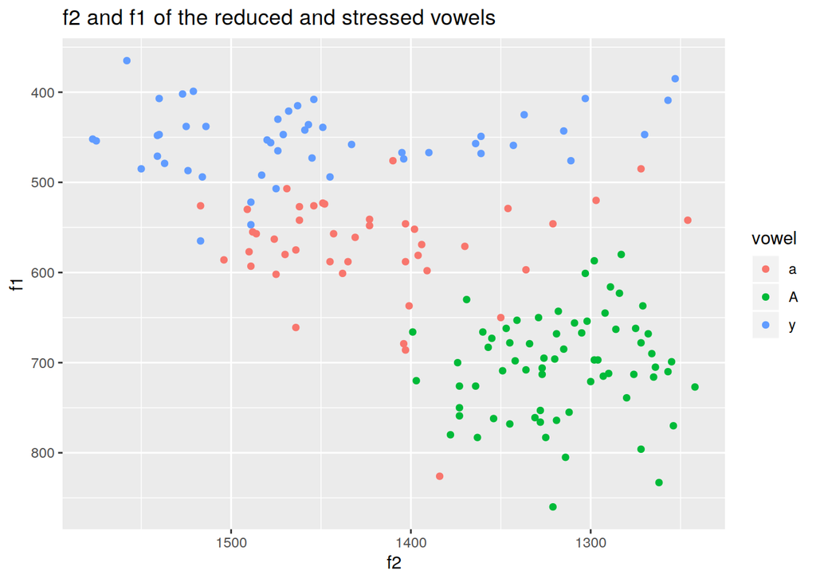

```r
ggplot(shva, aes(y = f1, x = f2, color = vowel)) +
  geom_point() +
  scale_x_continuous(trans = 'reverse') +
  scale_y_continuous(trans = 'reverse') +
  labs(title = 'f2 and f1 of the reduced and stressed vowels')
```

### 1.2

Plot the boxplots of `f1` and `f2` for each vowel using `ggplot()`. Design it to look like [this](https://raw.githubusercontent.com/agricolamz/2018-MAG_R_course/master/img/duryagin2.png) and [this](https://raw.githubusercontent.com/agricolamz/2018-MAG_R_course/master/img/duryagin3.png).

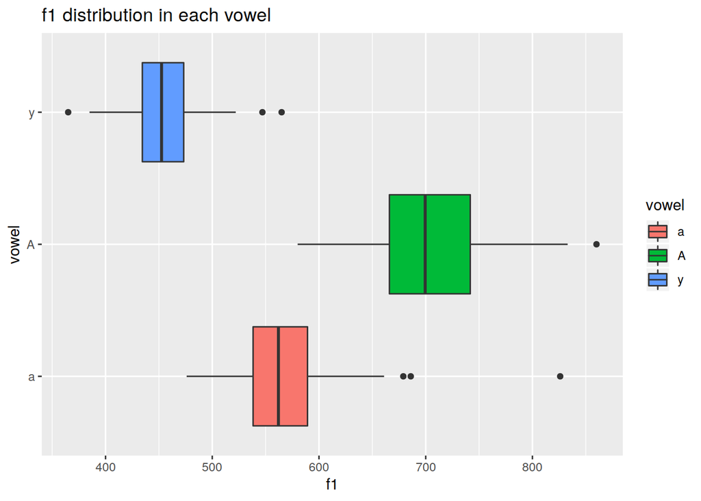

```r
# f1 boxplot
ggplot(shva, aes(x = vowel, y = f1, fill = vowel)) +
  geom_boxplot() +
  coord_flip() +
  labs(title = 'f1 distribution in each vowel')
```

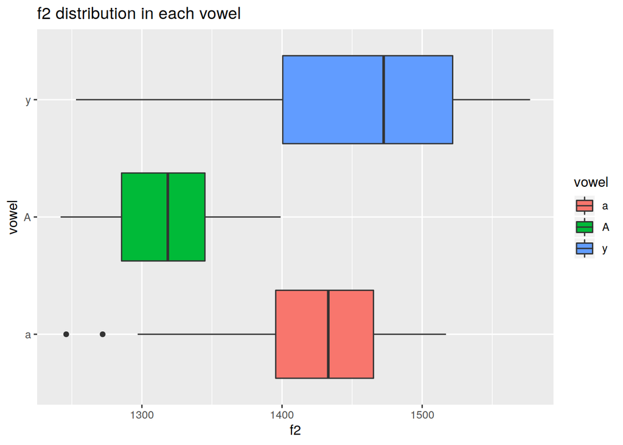

```r
# f2 boxplot
ggplot(shva, aes(x = vowel, y = f2, fill = vowel)) +
  geom_boxplot() +
  coord_flip() +
  labs(title = 'f2 distribution in each vowel')
```

### 1.3

Calculate Pearson’s correlation of `f1` and `f2` (all data)

```r
cor.test(shva$f1, shva$f2, method = 'pearson')
```

```
##
##  Pearson's product-moment correlation
##
## data:  shva$f1 and shva$f2
## t = -8.9437, df = 158, p-value = 9.533e-16
## alternative hypothesis: true correlation is not equal to 0
## 95 percent confidence interval:
##  -0.6742551 -0.4665570
## sample estimates:
##        cor
## -0.5797475
```

1.4 Calculate Pearson’s correlation of `f1` and `f2` for each vowel

```r
vowels = c()
results = c()

for (v in unique(shva$vowel)) {
  vowel <- shva %>%
    filter(vowel == v)
  t <- cor.test(vowel$f1, vowel$f2, method = 'pearson')
  vowels <- c(vowels, v)
  results <- c(results, t$estimate)
}

names(results) <- vowels

results
```

```
##           A           y           a
##  0.10327409  0.18187099 -0.01126545
```

## 2 Linear regressions

### 2.1.1

Use the linear regression model to predict `f2` by `f1`.

```r
model1 <- lm(data = shva, f2 ~ f1)
summary(model1)
```

```
##
## Call:
## lm(formula = f2 ~ f1, data = shva)
##
## Residuals:
##      Min       1Q   Median       3Q      Max
## -221.633  -46.447    6.354   54.352  131.093
##
## Coefficients:
##               Estimate Std. Error t value Pr(>|t|)
## (Intercept) 1639.70215   28.97365  56.593  < 2e-16 ***
## f1            -0.42875    0.04794  -8.944 9.53e-16 ***
## ---
## Signif. codes:  0 '***' 0.001 '**' 0.01 '*' 0.05 '.' 0.1 ' ' 1
##
## Residual standard error: 71.51 on 158 degrees of freedom
## Multiple R-squared:  0.3361, Adjusted R-squared:  0.3319
## F-statistic: 79.99 on 1 and 158 DF,  p-value: 9.533e-16
```

### 2.1.2

Write down the equation for f2 using coefficients from the model (e.g. $y = b + kx$)

```
y = 1639.70215 - 0.42875*x
```

### 2.1.3

Provide the adjusted R$^2$

```r
summary(model1)$adj.r.squared
```

```
## [1] 0.3319054
```

### 2.1.4

Add the regression line in the scatterplot 1.1.

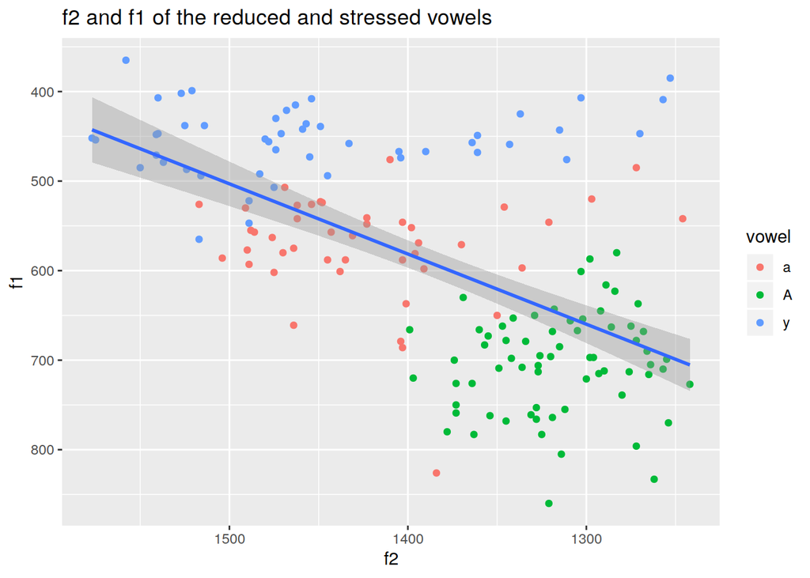

```r
ggplot(shva, aes(y = f1, x = f2)) +
  geom_point(aes(color = vowel)) +
  scale_x_continuous(trans = 'reverse') +
  scale_y_continuous(trans = 'reverse') +
  labs(title = 'f2 and f1 of the reduced and stressed vowels') +
  geom_smooth(method=lm)
```

### 2.1.5

Make a scatter plot for `f1` and `f2` grouped by vowels. Use `ggplot()` and `facet_wrap()`.

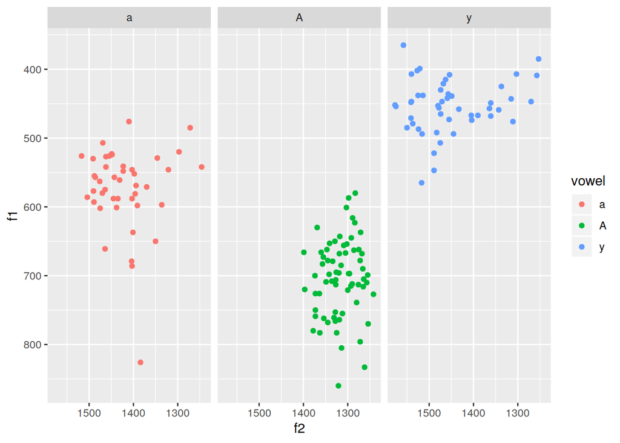

```r
ggplot(shva, aes(y = f1, x = f2)) +
  geom_point(aes(color = vowel)) +
  scale_x_continuous(trans = 'reverse') +
  scale_y_continuous(trans = 'reverse') +
  facet_wrap(~ vowel)
```

### 2.2.1

Use the linear regression model to predict `f2` by `f1` and `vowel`.

```r
model2 <- lm(data = shva, f2 ~ f1 + vowel)
summary(model2)
```

```
##
## Call:
## lm(formula = f2 ~ f1 + vowel, data = shva)
##
## Residuals:
##      Min       1Q   Median       3Q      Max
## -191.943  -27.517    7.175   42.891  125.625
##
## Coefficients:
##               Estimate Std. Error t value Pr(>|t|)
## (Intercept) 1365.91639   55.39963  24.656  < 2e-16 ***
## f1             0.09600    0.09523   1.008   0.3150
## vowelA      -117.39221   17.43344  -6.734 2.99e-10 ***
## vowely        42.06747   17.40696   2.417   0.0168 *
## ---
## Signif. codes:  0 '***' 0.001 '**' 0.01 '*' 0.05 '.' 0.1 ' ' 1
##
## Residual standard error: 63.08 on 156 degrees of freedom
## Multiple R-squared:  0.4899, Adjusted R-squared:  0.4801
## F-statistic: 49.94 on 3 and 156 DF,  p-value: < 2.2e-16
```

### 2.2.2

What is the intercept of the model?

```r
model2$coefficients[1]
```

```
## (Intercept)
##    1365.916
```

### 2.2.3

Provide the adjusted R$^2$

```r
summary(model2)$adj.r.squared
```

```
## [1] 0.4800681
```

### 2.2.4

Write down your general conclusions about the relationship between `f1`, `f2`, and `vowels`.

```
When we take into consideration a categorical variable "vowel" ("a" is set reference level) it becomes evident that f2 is not as much dependent on "f1" as it is on "vowel". We can come to this conclusion by looking at the coefficient values -- "f1" is much lower than "vowelA" and "vowely". The value intercept also differs considerably from the previous case where we utilized just one variable "f1".
```

## 3. Dutch causative constructions

When the Dutch use two near-synonymous periphrastic causative verbs, *doen* and *laten*?

```
       De politie deed/liet de auto stoppen.
  lit. the police did/let the car stop
       'The police stopped the car'
```

This is a data set on two rival constructions with *doen* and *laten* sampled from the newspaper corpora. The data frame includes 500 observations on the following 7 variables:

- `Aux` – verb: a factor with levels `doen` and `laten`
- `CrSem` – the semantic class of the Causer: a factor with levels `Anim` (animate) and `Inanim` (inanimate)
- `CeSem` – the semantic class of the Causee: a factor with levels `Anim` (animate) and `Inanim` (inanimate)
- `CdEvSem` – the semantic domain of the caused event expressed by the Effected Predicate: a factor with levels `Ment` (mental) and `NonMent` (e.g. physical or social)
- `CeSynt` – the syntactic status of the Causee: a factor with levels `Clause`, `Impl` (implicit, not expressed), `NP` (noun phrase), `PP` (prepositional phrase)
- `EPTrans` – transitivity or intransitivity of the effected predicate, a factor with two levels `Tr` and `Intr`
- `Country` – a factor with levels `BE` (Belgium) and `NL` (Netherlands)
- `Domain` – a factor with four levels for newspaper domains.

Data from Natalya Levshina’s `RLing` package available (here)[https://raw.githubusercontent.com/agricolamz/2018-MAG_R_course/master/data/dutch_causatives.csv] Read more on the constructions in [Levhina, Geerarts, Speelman 2014](https://www.academia.edu/7287585/Dutch_causative_constructions_Quantification_of_meaning_and_meaning_of_quantification_with_Dirk_Geeraerts_and_Dirk_Speelman_).

### 3.0

Read the data from file to the variable `d_caus`.

```r
d_caus <- read.csv("https://raw.githubusercontent.com/agricolamz/2018-MAG_R_course/master/data/dutch_causatives.csv")
summary(d_caus)
```

```
##     Aux         CrSem        CeSem        CdEvSem       CeSynt    EPTrans
##  doen : 85   Anim  :408   Anim  :317   Ment   :101   Clause: 22   Intr:239
##  laten:415   Inanim: 92   Inanim:183   NonMent:399   Impl  :134   Tr  :261
##                                                      NP    :268
##                                                      PP    : 76
##  Country  Domain
##  BE:220   E: 86
##  NL:280   F:116
##           M:150
##           P:148
```

### 3.1

We are going to test whether the association between `Aux` and other categorical variables (`Aux` ~ `CrSem`, `Aux` ~ `CeSem`, etc) is statistically significant. The association with which variable should be analysed using Fisher’s Exact Test and not using Pearson’s Chi-squared Test? Is this association statistically significant?

Answer:

Chi-squared test may give give incorrect approximation when the expected frequency is small (< 5). In such cases Fisher’s Exact Test is to be used. In the given dataset there is one such variable. If we use chi square on such data a warning is displayed.

```r
chisq.test(x = d_caus$Aux, y = d_caus$CeSynt)
```

```
## Warning in chisq.test(x = d_caus$Aux, y = d_caus$CeSynt): Chi-squared
## approximation may be incorrect
```

```
##
##  Pearson's Chi-squared test
##
## data:  d_caus$Aux and d_caus$CeSynt
## X-squared = 71.663, df = 3, p-value = 1.88e-15
```

```r
chisq.test(x = d_caus$Aux, y = d_caus$CeSynt)$expected
```

```
##           d_caus$CeSynt
## d_caus$Aux Clause   Impl     NP    PP
##      doen    3.74  22.78  45.56 12.92
##      laten  18.26 111.22 222.44 63.08
```

We see that there’s a very small expected value present, so we use Fisher’s test:

```r
fisher.test(x = d_caus$Aux, y = d_caus$CeSynt)
```

```
##
##  Fisher's Exact Test for Count Data
##
## data:  d_caus$Aux and d_caus$CeSynt
## p-value < 2.2e-16
## alternative hypothesis: two.sided
```

As we can see, p-value is less than $\alpha$. This means that the association between `Aux` and `CeSynt` is statistically significant.

### 3.2.

Test the hypothesis that `Aux` and `EPTrans` are not independent with the help of Pearson’s Chi-squared Test.

```r
ept <- chisq.test(x = d_caus$Aux, y = d_caus$EPTrans)
ept
```

```
##
##  Pearson's Chi-squared test with Yates' continuity correction
##
## data:  d_caus$Aux and d_caus$EPTrans
## X-squared = 14.307, df = 1, p-value = 0.0001553
```

Answer: `Aux` and `EPTrans` are dependent because p-value is less than $\alpha$.

### 3.3

Provide expected frequencies for Pearson’s Chi-squared Test of `Aux` and `EPTrans` variables.

```r
ept$expected
```

```
##           d_caus$EPTrans
## d_caus$Aux   Intr     Tr
##      doen   40.63  44.37
##      laten 198.37 216.63
```

### 3.4.

Calculate the odds ratio for observed frequencies of `Aux` and `EPTrans` For 2×2 contigency table
$$\begin{matrix}
a & b \\
c & d
\end{matrix}$$
one can find *odds ratio* as $(a/c)/(b/d)$.

```r
cont_caus <- table(d_caus$Aux, d_caus$EPTrans)
cont_caus
```

```
##
##         Intr  Tr
##   doen    57  28
##   laten  182 233
```

```r
cont_caus[1, 2]
```

```
## [1] 28
```

```r
odds_ratio <- (cont_caus[1, 1]/cont_caus[2, 1]) / (cont_caus[1, 2]/cont_caus[2, 2])
odds_ratio
```

```
## [1] 2.606162
```

### 3.4.1

Find odds ratio for expected frequencies of `Aux` and `EPTrans`

Answer: To better understand observed and expected frequencies I calculated this by hand. To find expected frequencies we can use use the following formula to evaluate the frequency in each cell $E_{ij} = \frac{T_i \cdot T_j}{N}$ where $E_{ij}$ is the cell in the i-th row and j-th column, $T_i$ is the total of i-th row, and $T_j$ is the total of j-th column. $N$ is the grand total of the table (i.e. the summ of all elements).

Let us calculate the totals of rows and columns.

```r
T_i_1 <- 57 + 28
T_i_2 <- 182 + 233
T_j_1 <- 57 + 182
T_j_2 <- 28 + 233
N <- sum(cont_caus)
paste(T_i_1, T_i_2, T_j_1, T_j_2, N)
```

```
## [1] "85 415 239 261 500"
```

And expected frequency for each cell.

```r
cell_1_1 <- (T_i_1 * T_j_1) / N
cell_1_2 <- (T_i_1 * T_j_2) / N
cell_2_1 <- (T_i_2 * T_j_1) / N
cell_2_2 <- (T_i_2 * T_j_2) / N
exp_caus <- matrix(c(cell_1_1, cell_1_2, cell_2_1, cell_2_2), nrow = 2, byrow = TRUE)
exp_caus
```

```
##        [,1]   [,2]
## [1,]  40.63  44.37
## [2,] 198.37 216.63
```

It matches the output of the function.

```r
exp_ept <- ept$expected
exp_ept
```

```
##           d_caus$EPTrans
## d_caus$Aux   Intr     Tr
##      doen   40.63  44.37
##      laten 198.37 216.63
```

The odds ratio for expected frequencies as follows:

```r
odds_ratio_exp <- (exp_ept[1, 1]/exp_ept[2, 1]) / (exp_ept[1, 2]/exp_ept[2, 2])
odds_ratio_exp
```

```
## [1] 1
```

We can see that the odds ratio is equal to one.

What can you say about odds ratio of expected frequencies for arbitrary data?

Answer: Odds ratio quantifies the strength of association between two events. If events are independent then odds ratio is equal to 1. If there’s association it’s greater or less than 1. So for arbitrary data it’s equal to 1 because it’s expected that there’s no association.

### 3.5

```r
library('rcompanion')
cramerV(d_caus$Aux, d_caus$EPTrans)
```

```
## Cramer V
##   0.1745
```

### 3.6.

Report the results of independence test using the following template:

```
        Intr  Tr
  doen    57  28
  laten  182 233
We have found a significant association between variables Aux and EPTrans (p < 0.001).  The odds of a predicate being intransitive were 2.6 times higher in doen group than in laten. Effect size is small (Cramer's V = 0.1745).
```

### 3.7

Visualize the distribution using mosaic plot. Use `mosaic()` function from `vcd` library.

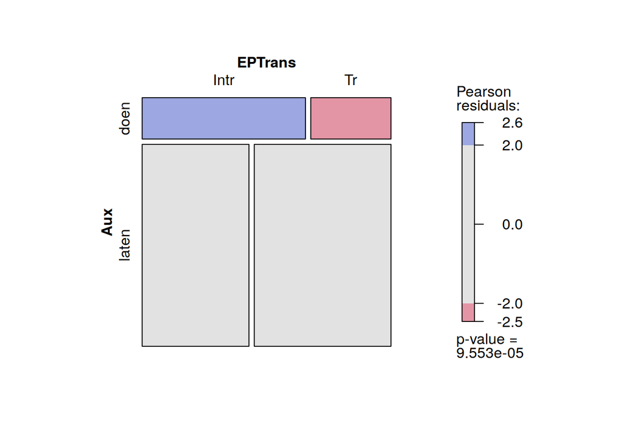

```r
mosaic(~ Aux + EPTrans, data=d_caus, shade=TRUE, legend=TRUE)
```

Below is an example of how to use mosaic() with three variables.

```r
# mosaic(~ Aux + CrSem + Country, data=d_caus, shade=TRUE, legend=TRUE)
```

### 3.8

Why is it not recommended to run multiple Chisq tests of independence on different variables within your dataset whithout adjusting for the multiplicity? (i.e. just testing all the pairs of variables one by one)

```
It is not recommended because the probabilyty to make a statistical error adds up with each additional value, thus we end up with an unreliable result.
```

### 3.9

Provide a short text (300 words) describing the hypothesis of this study and the results of your analysis.

[output not shown]